# ggplot2::geom_map()

Function of the Week

The geom_map() function is a tool for displaying polygons and developing basic maps

Author

Vincenzo Cornacchione

Published

February 7, 2024

# 1 `ggplot2::geom_map()`

In this document, I will introduce the `geom_map()` function and show what it’s for.

```r
# Load tidyverse up for ggplot2
library(tidyverse)
library(mapproj)
library(maps)
```

- The `mapproj` package allows R to convert latitude and longitude coordinates into projected coordinates (you might need to install it first).
- Installing `mapproj` should automatically also install the `maps` package, which allows you to access world map data. It’s a new version of the legacy map package `mapdata`, which you might still see used in example codes online.

## 1.1 What is it for?

The function `geom_map()` is similar to `geom_bar()` or `geom_smooth()` in the sense that it works like a predefined layout that tells the plot how to display your data. In this case, `geom_map()` displays polygons as a map.

## 1.2 But, what are polygons?

Polygons are **closed shapes** formed by connecting a series of points:

- They can represent various geographical features such as countries, states, or regions. - In the context of maps, polygons **define the boundaries of specific areas**.
- For example, the outline of a country on a world map is represented by a polygon. Each polygon consists of a **set of coordinates** (*latitude* and *longitude*) that define its shape.

Here’s a visual example of a polygon using `geom_map()` straight out of the R documentation:

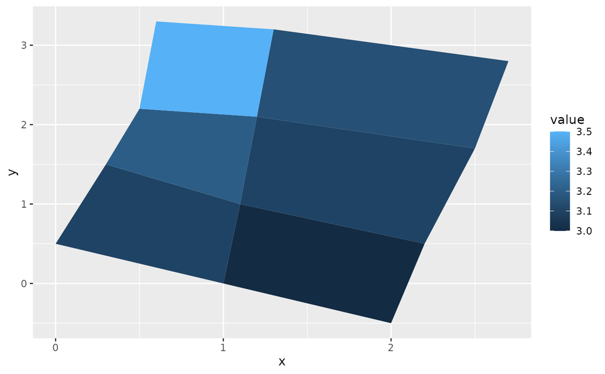

## 1.3 Displaying polygons as a map

Here we’ll walk through an example of creating a county map of Oregon:

> *Feel free to explore each step on your own to get comfortable with the functions (they were a bit confusing for me at first!)*

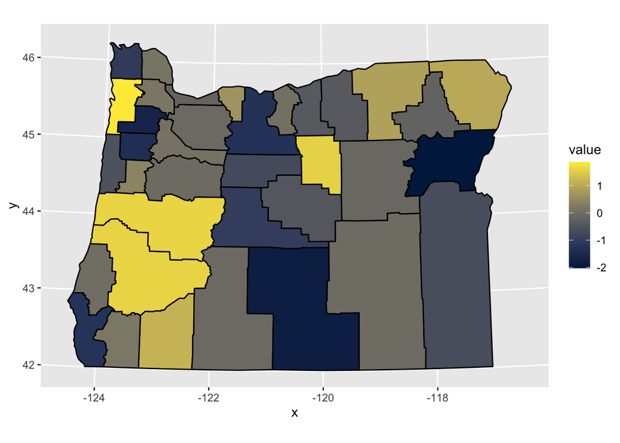

```r
# map_data() allows you to transform data from the maps package into a data frame
county_map <- map_data("county", "oregon")

# Rename "region" (state) and "subregion" (county) columns in county_map as state and id
names(county_map)[5:6] <- c("state", "id")

# Create a new data frame with county names and id (id values are needed for mapping aesthetics)
countyData <- data.frame(id = unique(county_map$id), value = rnorm(36))

# Now plot and develop the map
Oregonmap <- ggplot(countyData) +
  aes(map_id = id) +
  geom_map(aes(fill = value), map = county_map, colour = "black") +
  coord_map("polyconic") +                                         # Choose a coordinate system* (I recommend doing a Google search)
  expand_limits(x = county_map$long, y = county_map$lat)       +   # Setting units and adjusting the plot limits for the x and y axis
  scale_fill_viridis_c(option="E")                                 # Choose a color scale (for when you are plotting a map with actual data)

# Print the map~
print(Oregonmap)
```

> Code partially adapted from Uwe (2013) in [r - When should I use geom_map? - Stack Overflow](https://stackoverflow.com/questions/14698616/when-should-i-use-geom-map)

## 1.4 Is it helpful?

It’s a data visualization tool like any other - How useful `geom_map()` can be is ultimately *up to you* and *your audience*:

- From my experience, this function is a great way to include **simple**, **yet effective** maps to your reports (and student assignments!) whenever you are working with variables that are tied to regions around the world.
- Another bonus is that it is **great for beginners**. `geom_map()` leverages the familiar code structure and building blocks of `ggplot2`. For those (like me!) who might be intimated by more sophisticated functions such as `geom_sf()` or might not have access to mapping software like ArcGIS or Tableau, `geom_map()` is an accessible way to learn about *polygons*, *coordinate systems*, and basic mapping of spatial data.

If you are curious or want to learn more about `geom_map()` check out the R documentation. To learn about geom_sf(), check out these resources:

- Official 1geom_sf()` documentation: [Visualise sf objects — CoordSf • ggplot2 (tidyverse.org)](https://ggplot2.tidyverse.org/reference/ggsf.html)
- A quick and neat tutorial for `geom_sf()` where you can create a *proportional symbol map*: [Proportional symbol maps (bubble map) in ggplot2 (r-charts.com)](https://r-charts.com/spatial/proportional-symbol-map-ggplot2/)
- Geocomputation with R by Lovelace, Nowosad, and Muenchow (an online textbook!): [Geocomputation with R (bookdown.org)](https://bookdown.org/robinlovelace/geocompr/)